# 2017 GC Data Wrangling and outlier removal

# Check for compounds with low average Q-values

All compounds have mean Q-value > 90.

```r
gc_tidy.final %>%
  group_by(Compound) %>%
  summarize(meanQ = mean(QVal, na.rm = TRUE)) %>%
  arrange(meanQ)
```

| Compound | meanQ |
| --- | --- |
| Methyl jasmonate | 90.13651 |
| Pyrethrone | 90.44691 |
| Methyl anthranilate | 90.60190 |
| p-Cymen-8-ol | 90.69659 |
| Lavender Lactone | 90.87971 |
| Menthyl lactate | 91.00320 |
| 2-Heptanone, 4,6-dimethyl- | 91.24730 |
| Bicyclo[3.1.1]heptan-3-one, 2,6,6-trimethyl-, (1-alpha,2-beta,5-alpha) | 91.26683 |
| Hexenol | 91.27287 |
| 24 | 91.38193 |

[output cut: 300 more lines]

# Create wide data frame

```r
gc_wide <-
  gc_tidy.final %>%
  ungroup() %>%
  select(-rt, -ri, -No., -present, -CAS, -QVal) %>%
  spread(key = Compound, value = RPA)

gc_wide.zeroes <-
  gc_zeroes.final %>%
  ungroup %>%
  select(-rt, -ri, -No., -present, -CAS, -QVal) %>%
  spread(key = Compound, value = RPA)
```

# Outlier detection

## Multivariate normality

For some reason (data too large? numbers too small?) the `mvn()` function often fails due to a singular matrix error. Below, I’ve run it on random subsets of the data and log transformation seems to improve normality. Interestingly, scaling seems to make things worse.

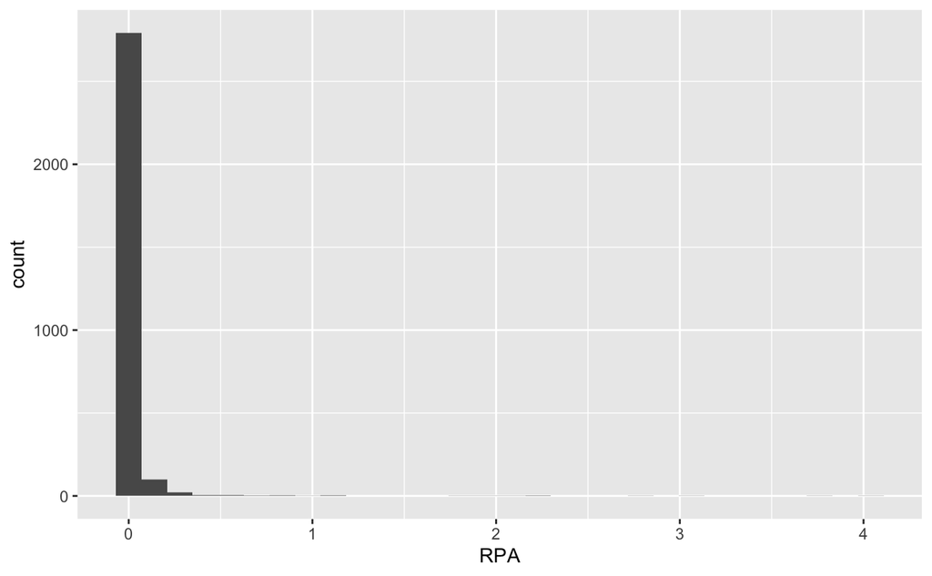

```r
gc_tidy.final %>%
  ggplot(aes(RPA)) + geom_histogram()
```

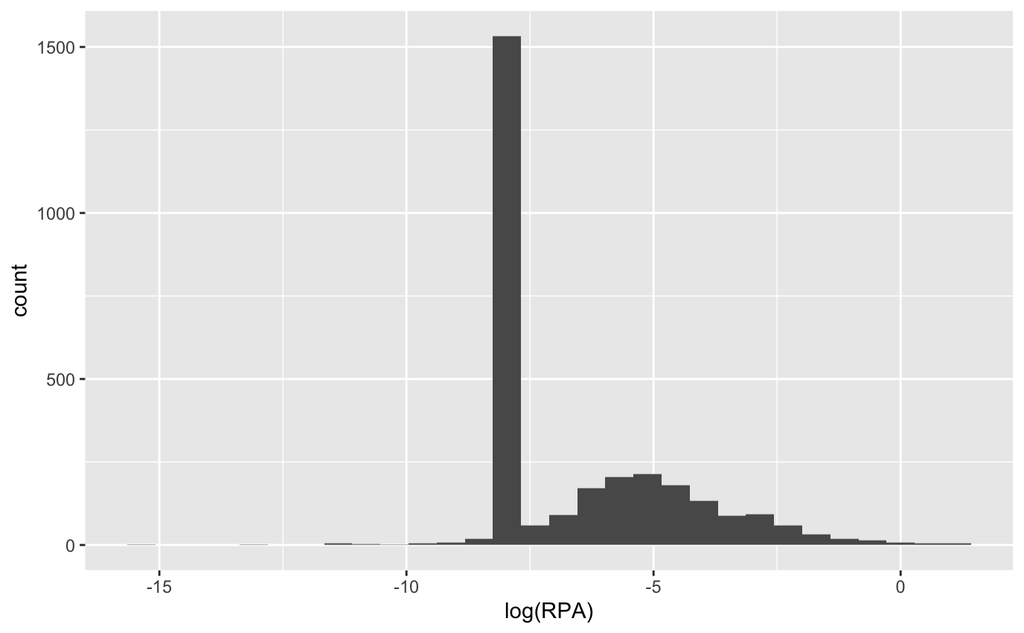

```r
gc_tidy.final %>%
  ggplot(aes(log(RPA))) + geom_histogram()
```

```r
metavars <- c("sample", "cultivar", "density_start", "density_end", "mean_percent_damage", "twister_damage")
```

```r
test <-
  gc_tidy.final %>%
  ungroup() %>%
  select(-rt, -ri, -No., -present, -CAS, -QVal) %>%
  spread(key = Compound, value = RPA) %>%
  select(-metavars) %>%
  # mutate_all(~.*1000) %>%
  mvn(mvnTest = "mardia",
      transform = "log",
      multivariatePlot = "qq",
      scale = TRUE)
test
```

[output not shown]

So this dataset is clearly zero-inflated (or rather, small number introduced by data pre-treatment inflated). I should consider distance-based methods as a sanity-check.

## Multivariate outlier detection

Using Leland Wilkinson’s algorithm from `HDoutliers`

```r
library(HDoutliers)
out1 <- HDoutliers(select(gc_wide, -metavars), alpha = 0.1)
gc_wide[out1, ]$sample
```

```
[1] "Q8"
```

```r
#after log transformation
out2 <- HDoutliers(select(gc_wide, -metavars) %>% mutate_all(log), alpha = 0.1)
gc_wide[out2, ]
```

| sample | cultivar | density_start | density_end | mean_percent_damage | twister_damage | 1-Hexanol | 1-Hexanol, 2-ethyl- | 1-Nonanol | 1-Octanol | 1,2-Cyclopentanedione | 1,2,4-Trimethylbenzene | 10,18-Bisnorabieta-8,11,13-triene | 118 | 13 (DCSE) | 145 | 151 | 168 | 197 | 1H-Pyrrole, 2-methyl- | 2 (DCSE) | 2-Butenal, 3-methyl- | 2-Cyclohexen-1-ol | 2-Cyclopenten-1-one | 2-Cyclopenten-1-one, 2-hydroxy- | 2-Cyclopentene-1,4-dione | 2-Furanmethanol | 2-Hydroxy-gamma-butyrolactone | 2-Methoxy-4-vinylphenol | 2-Octen-1-ol, (E)- | … |
| --- | --- | --- | --- | --- | --- | --- | --- | --- | --- | --- | --- | --- | --- | --- | --- | --- | --- | --- | --- | --- | --- | --- | --- | --- | --- | --- | --- | --- | --- | --- |

Q8 is possible outlier

## With PCA

```r
library(ropls)
pca.1 <- opls(select(gc_wide, -metavars), scaleC = "standard", plotL = FALSE)
```

```
'plotL' argument is deprecated; use 'fig.pdfC' instead
```

```
PCA
19 samples x 155 variables
standard scaling of predictors
```

|  | R2X(cum) | pre | ort |
| --- | --- | --- | --- |
| Total | 0.523 | 4 | 0 |

```r
pca.2 <-
  gc_wide %>%
  select(-metavars) %>%
  mutate_all(log) %>%
  opls(scaleC = "standard", plotL = FALSE)
```

```
'plotL' argument is deprecated; use 'fig.pdfC' instead
```

```
PCA
19 samples x 155 variables
standard scaling of predictors
```

|  | R2X(cum) | pre | ort |
| --- | --- | --- | --- |
| Total | 0.561 | 5 | 0 |

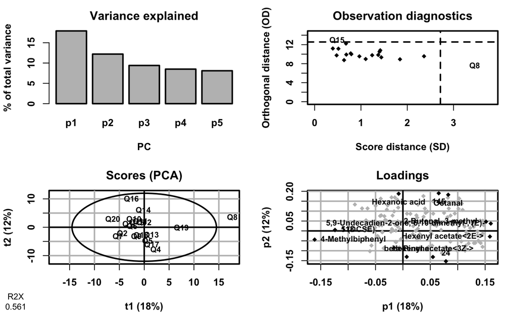

```r
plot(pca.2, parLabVc = gc_wide$sample)#log transformed
```

```r
# plot(pca.1, parLabVc = gc_wide$sample)
```

Q8 is a pretty strong outlier.

# Write to file

```r
write_rds(gc_wide, here("data", "cleaned", "2017_gcms_wide.rds"))
write_rds(gc_tidy.final, here("data", "cleaned", "2017_gcms_tidy.rds"))
write_rds(gc_wide.zeroes, here("data", "cleaned", "2017_gcms_zeroes.rds"))
```